# Exploring the BRFSS data

```r
#Then, accordingly with the data, we can see that mental health is not directly associated with binge drinking. We can say, just, that the correlation between binge drinking and mental health are a little higher than correlation between binge drinking and physical health.
```

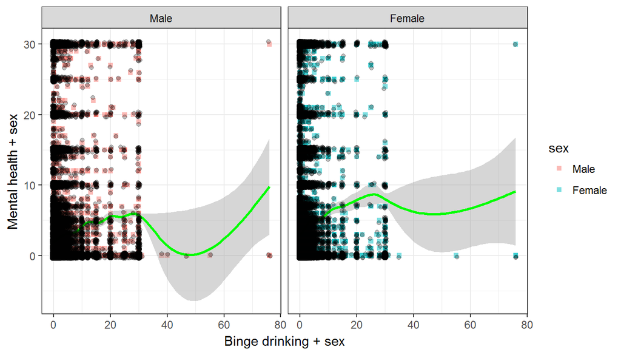

```r
#And now, we will viz our data:


ggplot(brfss2013_sel, aes(drnk3ge5, menthlth)) + geom_point(shape = 15, alpha = 0.5,aes(colour = sex)) + geom_smooth(color = "green") + facet_grid(.~sex) + geom_jitter(alpha = 0.25) + theme_bw() + labs(x = "Binge drinking + sex", y = "Mental health + sex")
```

```r
#Conclusion

#Although the things we see above, we can see here, at these plots, that mental health can affect a little the influence of binge drinking. In this case we can see rare cases, that makes the data biased.
```

**Research question 3:**

```r
#Descriptive analysis

#preparing the data

brfss2013_sel <- brfss2013_sel %>%
  mutate(phys_hlth = ifelse(physhlth <= 5, 'low_physhlth',
                    ifelse(drnk3ge5 > 5 && drnk3ge5 <= 20, 'mid_physhlth', 'high_physhlth' )))


#looking at the physical health, regardless of sex

brfss2013_sel_group <- brfss2013_sel %>%
  group_by(phys_hlth, beverage) %>%
  summarise(count = n()) %>%
  arrange(desc(count))

brfss2013_sel_group
```

```
## Source: local data frame [4 x 3]
## Groups: phys_hlth [2]
##
##       phys_hlth      beverage  count
##           <chr>         <chr>  <int>
## 1  low_physhlth  low_beverage 135573
## 2 high_physhlth  low_beverage  21142
## 3  low_physhlth high_beverage    875
## 4 high_physhlth high_beverage    268
```

```r
#testing hypothesis

#good physical health and small fractions of beverage

#bad physical health and small fractions of beverage

df_beverage_low = brfss2013_sel$drnk3ge5 <= 26

df_physhlth_high = brfss2013_sel$physhlth >= 20

df_physhlth_low = brfss2013_sel$physhlth <= 5


#correlations


bad_phys_health_cor <- cor(df_beverage_low,df_physhlth_high)
bad_phys_health_cor
```

```
## [1] -0.03132894
```

```r
good_phys_health_cor <- cor(df_beverage_low, df_physhlth_low)
good_phys_health_cor
```

```
## [1] 0.02465393
```

```r
#These values is not very significant.
```

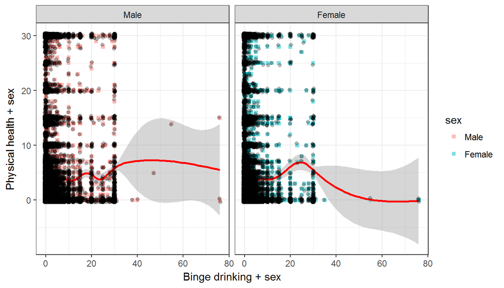

```r
#And now, we will viz our data:

ggplot(brfss2013_sel, aes(drnk3ge5, physhlth)) + geom_point(shape = 15, alpha = 0.5,aes(colour = sex)) + geom_smooth(color = "red") + facet_grid(.~sex) + geom_jitter(alpha = 0.25) + theme_bw() + labs(x = "Binge drinking + sex", y = "Physical health + sex")
```

```r
#Conclusion

#Again, the data is not conclusive, the pointing is that binge drinking doesn't affect physical health, but as the data says, it could be true, but it's hard to point a fact as a real truth, because we need more consistency, we are looking for a general form, with no distinctions. If you merge a pub data, with a hospital, we could be more assertive, as such as you know exactly who people is drinking and who needs hospital care. But, even so, we can consider that a small fraction of this data, could show us that the health of people that don't get drunk, is better. As wee see, there's a little correlation between physical health and binge drinking and, mental health and binge drinking, but this doesn't reflects nothing with each other.
```

Variables:

ladult: Are You 18 Years Of Age Or Older? nummen: Number Of Adult Men In Household numwomen: Number Of Adult Women In Household sex: Respondents Sex genhlth: General Health physhlth: Number Of Days Physical Health Not Good menthlth: Number Of Days Mental Health Not Good drnk3ge5: Binge Drinking

Source: https://d3c33hcgiwev3.cloudfront.net/_e34476fda339107329fc316d1f98e042_brfss_codebook.html?Expires=1499558400&Signature=fN48BqjlDlCnYWplYvdGaimE1k3419EzppGU4zvQRvZYf1zCRn2rLOIn3gZsfhdXPvRvfVeJ4ue17czMaVD892RRbOx7bv5U6bUjoaxuXH97FKSWCB8eL32FoFdPnu9loiRvhL0qcX7pnV~fTeZbqYegl9ckRpqyTFAwCyLTB1I_&Key-Pair-Id=APKAJLTNE6QMUY6HBC5A

References:

https://www.cdc.gov/brfss/data_documentation/index.htm

https://www.cdc.gov/brfss/data_documentation/pdf/userguidejune2013.pdf

https://www.cdc.gov/brfss/questionnaires/pdf-ques/2016_brfss_questionnaire_final.pdf

https://www.openintro.org/download.php?file=os2_labSAS_01A&referrer=/stat/labs.php

Thank you for your attention!

Best Regards.

Ernâni